# betting

```python
import pandas as pd
import numpy as np

import matplotlib.pyplot as plt
import seaborn as sns
```

```python
import math
from sklearn.linear_model import LogisticRegression as LogReg
from sklearn.metrics import log_loss
from sklearn.preprocessing import OneHotEncoder
from sklearn.model_selection import train_test_split
from sklearn.ensemble import RandomForestClassifier as rf_classifier, AdaBoostClassifier as adaboost_clf
from sklearn.model_selection import cross_validate, GridSearchCV as gridCV
from sklearn.metrics import f1_score, precision_score, recall_score

from sklearn.tree import DecisionTreeClassifier as dtree_clf
from sklearn import tree
from imblearn.over_sampling import SMOTE
from xgboost import XGBClassifier as xgboost_clf
import xgboost as xgb
```

```python
from autoplotter import run_app
```

```python
df = pd.read_csv('betting_platform_activity.csv')
```

```python
# run_app(df)
```

```python
df.sample(5)
```

|  | effort_category | occupation | coins_earned | peer_category | bank_category | completed_games | started_games | session_time | games_last_90days | games_last_120days | ... | games_last_366days | angry_birds | cars | cricket | football | snooker | hockey | uninstalled_next_60d | age_rounded_closest_ten | fun_quotient |
| --- | --- | --- | --- | --- | --- | --- | --- | --- | --- | --- | --- | --- | --- | --- | --- | --- | --- | --- | --- | --- | --- |
| 13944 | MEDIUM | Private Sector Service | -244 | tier ii | Scheduled Private Bank | 26 | 87 | 906 | 0 | 0 | ... | 0 | 0 | 0 | 8 | 18 | 0 | 0 | 1 | 20 | 2 |
| 2062 | MEDIUM | 0 | 0 | tier iii | Scheduled PSU | 5 | 6 | 21 | 0 | 0 | ... | 0 | 0 | 0 | 1 | 4 | 0 | 0 | 1 | 20 | 2 |
| 8356 | MEDIUM | Private Sector Service | -367 | tier ii | Scheduled PSU | 34 | 152 | 2985 | 0 | 0 | ... | 0 | 0 | 0 | 32 | 2 | 0 | 0 | 1 | 20 | 3 |
| 7605 | MEDIUM | Private Sector Service | 2 | tier i | Scheduled PSU | 55 | 127 | 2036 | 2 | 20 | ... | 0 | 0 | 34 | 9 | 12 | 0 | 0 | 0 | 20 | 3 |
| 16555 | LOW | Business | -15 | tier ii | Scheduled Private Bank | 43 | 98 | 668 | 12 | 9 | ... | 0 | 0 | 3 | 7 | 33 | 0 | 0 | 0 | 20 | 1 |

5 rows × 27 columns

# EDA

```python
df.dtypes
```

```
effort_category            object
occupation                 object
coins_earned                int64
peer_category              object
bank_category              object
completed_games             int64
started_games               int64
session_time                int64
games_last_90days           int64
games_last_120days          int64
games_last_150days          int64
games_last_180days          int64
games_last_210days          int64
games_last_240days          int64
games_last_270days          int64
games_last_300days          int64
games_last_330days          int64
games_last_366days          int64
angry_birds                 int64
cars                        int64
cricket                     int64
football                    int64
snooker                     int64
hockey                      int64
uninstalled_next_60d        int64
age_rounded_closest_ten     int64
fun_quotient                int64
dtype: object
```

```python
df.isna().sum()
```

```
effort_category            0
occupation                 0
coins_earned               0
peer_category              0
bank_category              0
completed_games            0
started_games              0
session_time               0
games_last_90days          0
games_last_120days         0
games_last_150days         0
games_last_180days         0
games_last_210days         0
games_last_240days         0
games_last_270days         0
games_last_300days         0
games_last_330days         0
games_last_366days         0
angry_birds                0
cars                       0
cricket                    0
football                   0
snooker                    0
hockey                     0
uninstalled_next_60d       0
age_rounded_closest_ten    0
fun_quotient               0
dtype: int64
```

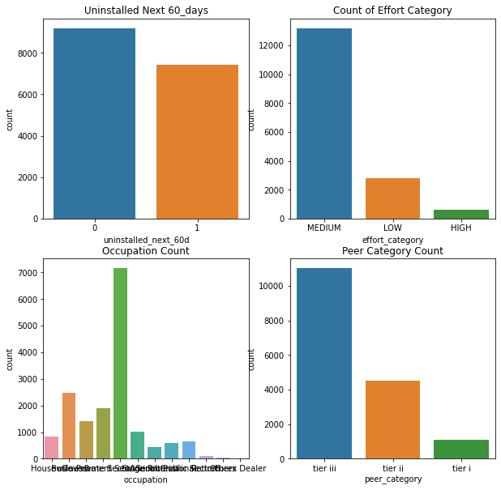

```python
# fig,ax=plt.subplots(1,2,figsize=(15,10))
# sns.scatterplot(data=df_copy, y='session_time',x='completed_games', hue='uninstalled_next_60d',ax=ax[0])
# sns.scatterplot(data=df_copy, y='session_time',x='coins_earned', hue='uninstalled_next_60d', ax=ax[1])
# plt.show()


fig,ax = plt.subplots(2,2, figsize=(10,10))

sns.countplot(x='uninstalled_next_60d', data=df, ax=ax[0][0]).set_title('Uninstalled Next 60_days')
sns.countplot(x='effort_category', data=df, ax=ax[0][1]).set_title('Count of Effort Category')
sns.countplot(x='occupation', data=df, ax=ax[1][0]).set_title('Occupation Count')
sns.countplot(x='peer_category', data=df, ax=ax[1][1]).set_title('Peer Category Count')

plt.show()
```

## Almost equal number of samples are available for both the classes. There is no need for dealing with imbalance classificiation

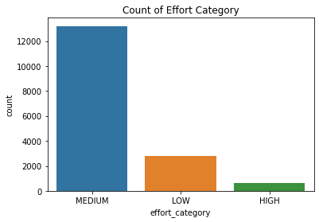

```python
sns.countplot(x='effort_category', data=df).set_title('Count of Effort Category')
```

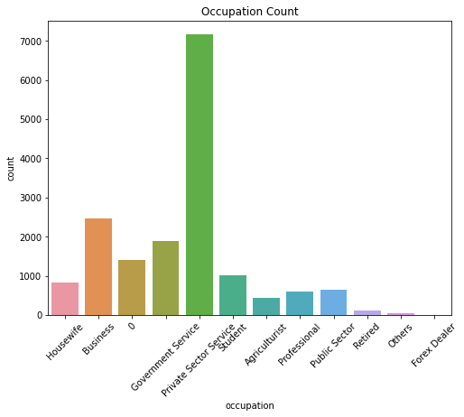

```python
plt.figure(figsize=(8,6))
sns.countplot(x='occupation', data=df).set_title('Occupation Count')
plt.xticks(rotation=45)
plt.show()
```

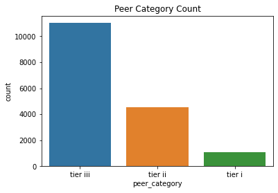

```python
sns.countplot(x='peer_category', data=df).set_title('Peer Category Count')
```

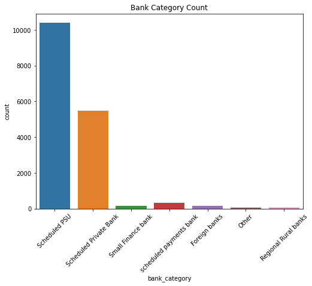

```python
plt.figure(figsize=(8,6))
sns.countplot(x='bank_category', data=df).set_title('Bank Category Count')
plt.xticks(rotation=45)
plt.show()
```

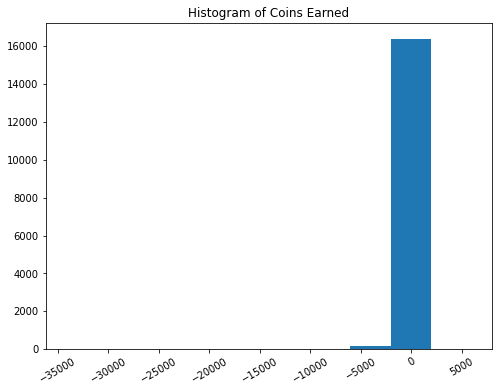

```python
plt.figure(figsize=(8,6))
plt.hist(x='coins_earned', data=df)
plt.title('Histogram of Coins Earned')
plt.xticks(rotation=30)
plt.show()
```

```python
df.groupby('effort_category').agg({'coins_earned':'sum'}).reset_index()
```

|  | effort_category | coins_earned |
| --- | --- | --- |
| 0 | HIGH | -71204 |
| 1 | LOW | -323502 |
| 2 | MEDIUM | -1201725 |

```python
df.groupby('effort_category').agg({'coins_earned':'mean'}).reset_index()
```

|  | effort_category | coins_earned |
| --- | --- | --- |
| 0 | HIGH | -116.346405 |
| 1 | LOW | -114.717021 |
| 2 | MEDIUM | -91.074271 |

## On an average, people lose more coins than gaining coins

```python
print(df[df['angry_birds']==1]['fun_quotient'].unique())
print(df[df['cars']==1]['fun_quotient'].unique())
print(df[df['cricket']==1]['fun_quotient'].unique())
print(df[df['football']==1]['fun_quotient'].unique())
print(df[df['snooker']==1]['fun_quotient'].unique())
print(df[df['hockey']==1]['fun_quotient'].unique())
```

```
[4 3 2 1 5]
[2 3 4 1 5]
[2 3 4 1 5 0]
[2 1 3 4 5 0]
[2 3 1 4 5]
[]
```

### - Nobody on the platform is playing hockey

### - Games are being played in the following order: Football > Cars > Cricket > Angry Birds > Snooker > Hockey

```python
print(sum(df['angry_birds']))
print(sum(df['cars']))
print(sum(df['cricket']))
print(sum(df['football']))
print(sum(df['snooker']))
print(sum(df['hockey']))
```

```
5344
285743
193847
302975
3076
0
```

```python
df.describe()
```

|  | coins_earned | completed_games | started_games | session_time | games_last_90days | games_last_120days | games_last_150days | games_last_180days | games_last_210days | games_last_240days | ... | games_last_366days | angry_birds | cars | cricket | football | snooker | hockey | uninstalled_next_60d | age_rounded_closest_ten | fun_quotient |
| --- | --- | --- | --- | --- | --- | --- | --- | --- | --- | --- | --- | --- | --- | --- | --- | --- | --- | --- | --- | --- | --- |
| count | 16627.000000 | 16627.000000 | 16627.000000 | 16627.000000 | 16627.000000 | 16627.000000 | 16627.000000 | 16627.000000 | 16627.000000 | 16627.000000 | ... | 16627.0 | 16627.000000 | 16627.000000 | 16627.000000 | 16627.000000 | 16627.000000 | 16627.0 | 16627.000000 | 16627.000000 | 16627.000000 |
| mean | -96.014374 | 48.557647 | 271.835208 | 4392.486378 | 6.745354 | 7.031936 | 6.148914 | 6.835388 | 8.109400 | 2.556324 | ... | 0.0 | 0.321405 | 17.185481 | 11.658567 | 18.221868 | 0.185000 | 0.0 | 0.446382 | 23.722860 | 2.158658 |
| std | 679.096448 | 49.619382 | 507.211211 | 9792.571283 | 9.723335 | 9.828378 | 8.538361 | 8.211047 | 8.696467 | 4.829301 | ... | 0.0 | 3.658547 | 31.671478 | 17.689951 | 24.090851 | 2.315993 | 0.0 | 0.497132 | 6.276417 | 0.480052 |
| min | -34202.000000 | 0.000000 | 0.000000 | 0.000000 | 0.000000 | 0.000000 | 0.000000 | 0.000000 | 0.000000 | 0.000000 | ... | 0.0 | 0.000000 | 0.000000 | 0.000000 | 0.000000 | 0.000000 | 0.0 | 0.000000 | 20.000000 | 0.000000 |
| 25% | -43.000000 | 12.000000 | 28.000000 | 60.000000 | 0.000000 | 0.000000 | 0.000000 | 0.000000 | 1.000000 | 0.000000 | ... | 0.0 | 0.000000 | 0.000000 | 2.000000 | 2.000000 | 0.000000 | 0.0 | 0.000000 | 20.000000 | 2.000000 |
| 50% | -1.000000 | 32.000000 | 96.000000 | 760.000000 | 2.000000 | 2.000000 | 2.000000 | 4.000000 | 5.000000 | 0.000000 | ... | 0.0 | 0.000000 | 0.000000 | 4.000000 | 8.000000 | 0.000000 | 0.0 | 0.000000 | 20.000000 | 2.000000 |
| 75% | 5.000000 | 71.000000 | 297.000000 | 4461.500000 | 11.000000 | 11.500000 | 10.000000 | 11.000000 | 12.000000 | 3.000000 | ... | 0.0 | 0.000000 | 21.000000 | 13.000000 | 25.000000 | 0.000000 | 0.0 | 1.000000 | 30.000000 | 2.000000 |
| max | 5993.000000 | 461.000000 | 11804.000000 | 236040.000000 | 97.000000 | 85.000000 | 87.000000 | 64.000000 | 67.000000 | 51.000000 | ... | 0.0 | 129.000000 | 250.000000 | 152.000000 | 163.000000 | 101.000000 | 0.0 | 1.000000 | 40.000000 | 5.000000 |

8 rows × 23 columns

```python
df['effort_category'].unique()
```

```
array(['MEDIUM', 'LOW', 'HIGH'], dtype=object)
```

```python
pd.crosstab(df['effort_category'], df['uninstalled_next_60d'], margins=True)
```

| uninstalled_next_60d effort_category | 0 | 1 | All |
| --- | --- | --- | --- |
| HIGH | 326 | 286 | 612 |
| LOW | 1563 | 1257 | 2820 |
| MEDIUM | 7316 | 5879 | 13195 |
| All | 9205 | 7422 | 16627 |

```python
pd.crosstab(df['occupation'], df['uninstalled_next_60d'], margins=True)
```

| uninstalled_next_60d occupation | 0 | 1 | All |
| --- | --- | --- | --- |
| 0 | 731 | 665 | 1396 |
| Agriculturist | 244 | 203 | 447 |
| Business | 1342 | 1121 | 2463 |
| Forex Dealer | 1 | 0 | 1 |
| Government Service | 1106 | 787 | 1893 |
| Housewife | 551 | 286 | 837 |
| Others | 33 | 22 | 55 |
| Private Sector Service | 3961 | 3197 | 7158 |
| Professional | 330 | 265 | 595 |
| Public Sector | 359 | 281 | 640 |
| Retired | 77 | 41 | 118 |
| Student | 470 | 554 | 1024 |
| All | 9205 | 7422 | 16627 |

```python
pd.crosstab(df['peer_category'], df['uninstalled_next_60d'], margins=True)
```

| uninstalled_next_60d peer_category | 0 | 1 | All |
| --- | --- | --- | --- |
| tier i | 613 | 462 | 1075 |
| tier ii | 2602 | 1930 | 4532 |
| tier iii | 5990 | 5030 | 11020 |
| All | 9205 | 7422 | 16627 |

```python
pd.crosstab(df['bank_category'], df['uninstalled_next_60d'], margins=True)
```

| uninstalled_next_60d bank_category | 0 | 1 | All |
| --- | --- | --- | --- |
| Foreign banks | 83 | 76 | 159 |
| Other | 45 | 26 | 71 |
| Regional Rural banks | 27 | 19 | 46 |
| Scheduled PSU | 5698 | 4697 | 10395 |
| Scheduled Private Bank | 3120 | 2344 | 5464 |
| Small Finance bank | 95 | 67 | 162 |
| scheduled payments bank | 137 | 193 | 330 |
| All | 9205 | 7422 | 16627 |

```python
df.columns
```

```
Index(['effort_category', 'occupation', 'coins_earned', 'peer_category',
       'bank_category', 'completed_games', 'started_games', 'session_time',
       'games_last_90days', 'games_last_120days', 'games_last_150days',
       'games_last_180days', 'games_last_210days', 'games_last_240days',
       'games_last_270days', 'games_last_300days', 'games_last_330days',
       'games_last_366days', 'angry_birds', 'cars', 'cricket', 'football',
       'snooker', 'hockey', 'uninstalled_next_60d', 'age_rounded_closest_ten',
       'fun_quotient'],
      dtype='object')
```

```python
categorical_var = ['effort_category', 'occupation', 'peer_category', 'bank_category']

df_copy = pd.get_dummies(df, columns=categorical_var)
```

```python
df_copy.columns
```

```
Index(['coins_earned', 'completed_games', 'started_games', 'session_time',
       'games_last_90days', 'games_last_120days', 'games_last_150days',
       'games_last_180days', 'games_last_210days', 'games_last_240days',
       'games_last_270days', 'games_last_300days', 'games_last_330days',
       'games_last_366days', 'angry_birds', 'cars', 'cricket', 'football',
       'snooker', 'hockey', 'uninstalled_next_60d', 'age_rounded_closest_ten',
       'fun_quotient', 'effort_category_HIGH', 'effort_category_LOW',
       'effort_category_MEDIUM', 'occupation_0', 'occupation_Agriculturist',
       'occupation_Business', 'occupation_Forex Dealer',
       'occupation_Government Service', 'occupation_Housewife',
       'occupation_Others', 'occupation_Private Sector Service',
       'occupation_Professional', 'occupation_Public Sector',
       'occupation_Retired', 'occupation_Student', 'peer_category_tier i',
       'peer_category_tier ii', 'peer_category_tier iii',
       'bank_category_Foreign banks', 'bank_category_Other',
       'bank_category_Regional Rural banks', 'bank_category_Scheduled PSU',
       'bank_category_Scheduled Private Bank',
       'bank_category_Small Finance bank',
       'bank_category_scheduled payments bank'],
      dtype='object')
```

### Additional dummy variables are dropped as number of dummy variables should be n-1. If the categorical variable has 3 unique values, only 2 dummy variables are generated.

```python
df_copy = df_copy.drop(columns=['occupation_0','effort_category_LOW', 'peer_category_tier iii', 'bank_category_Other'])
```

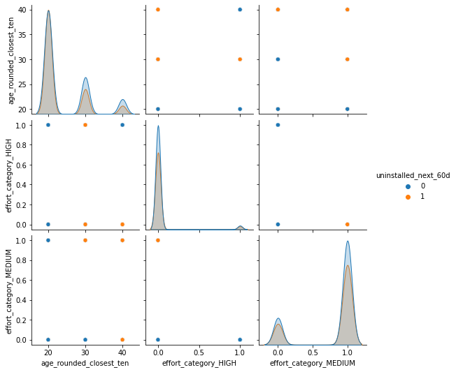

```python
cols = ["age_rounded_closest_ten",'effort_category_HIGH','effort_category_MEDIUM','occupation_Agriculturist','occupation_Business',
        'occupation_Government Service','occupation_Housewife', 'occupation_Others', 'occupation_Private Sector Service', 'occupation_Professional',
        'occupation_Public Sector', 'occupation_Retired', 'occupation_Student', 'peer_category_tier i','peer_category_tier ii',
        'bank_category_Foreign banks','bank_category_Regional Rural banks', 'bank_category_Scheduled PSU','bank_category_Scheduled Private Bank',
        'bank_category_Small Finance bank','bank_category_scheduled payments bank','uninstalled_next_60d' ]

cols_1 = ["age_rounded_closest_ten",'effort_category_HIGH','effort_category_MEDIUM','uninstalled_next_60d' ]

sns.pairplot(df_copy.loc[:,cols_1], hue="uninstalled_next_60d")
plt.show()
```

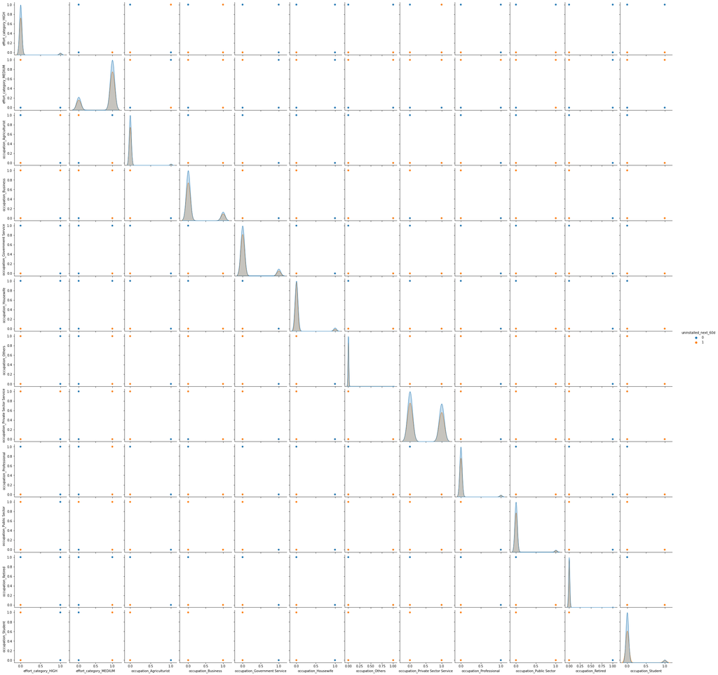

```python
cols = ['effort_category_HIGH','effort_category_MEDIUM','occupation_Agriculturist','occupation_Business',
        'occupation_Government Service','occupation_Housewife', 'occupation_Others', 'occupation_Private Sector Service', 'occupation_Professional',
        'occupation_Public Sector', 'occupation_Retired', 'occupation_Student','uninstalled_next_60d' ]

sns.pairplot(df_copy.loc[:,cols], hue="uninstalled_next_60d")
plt.show()
```

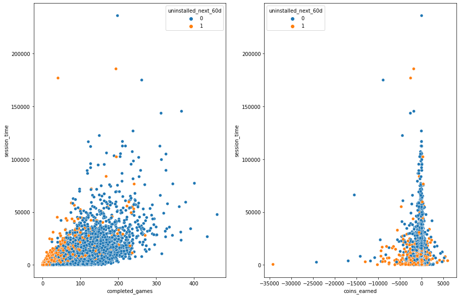

```python
fig,ax=plt.subplots(1,2,figsize=(15,10))
sns.scatterplot(data=df_copy, y='session_time',x='completed_games', hue='uninstalled_next_60d',ax=ax[0])
sns.scatterplot(data=df_copy, y='session_time',x='coins_earned', hue='uninstalled_next_60d', ax=ax[1])
plt.show()
```

```python
df.columns
```

```
Index(['effort_category', 'occupation', 'coins_earned', 'peer_category',
       'bank_category', 'completed_games', 'started_games', 'session_time',
       'games_last_90days', 'games_last_120days', 'games_last_150days',
       'games_last_180days', 'games_last_210days', 'games_last_240days',
       'games_last_270days', 'games_last_300days', 'games_last_330days',
       'games_last_366days', 'angry_birds', 'cars', 'cricket', 'football',
       'snooker', 'hockey', 'uninstalled_next_60d', 'age_rounded_closest_ten',
       'fun_quotient'],
      dtype='object')
```

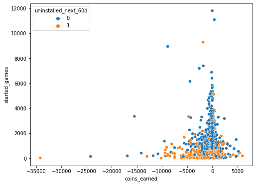

```python
plt.figure(figsize=(8,6))
sns.scatterplot(data=df_copy, x='coins_earned', y='started_games', hue='uninstalled_next_60d')
plt.show()
```

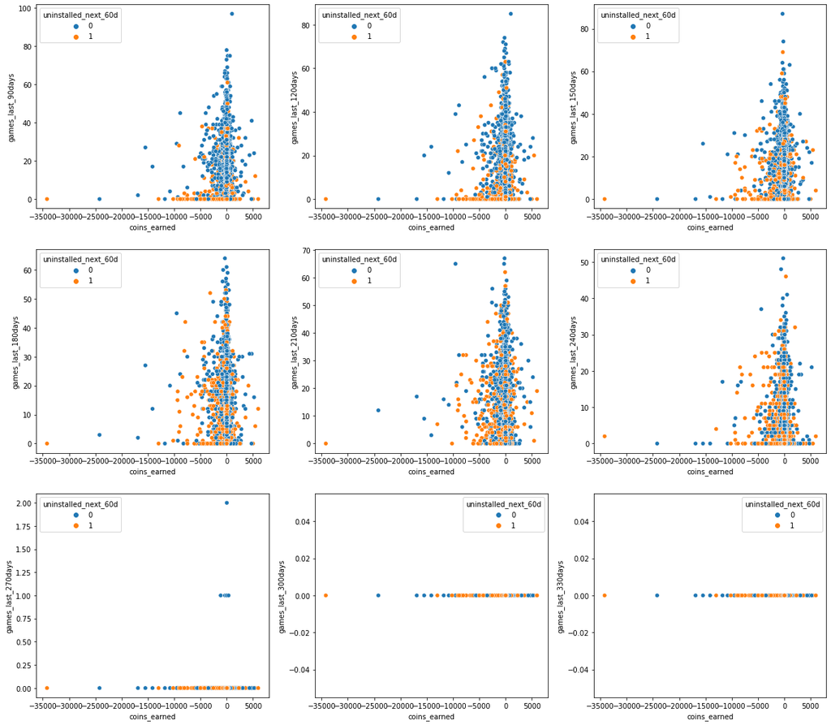

```python
fig,ax=plt.subplots(3,3,figsize=(20,18))
sns.scatterplot(data=df_copy, y='games_last_90days', x='coins_earned', hue='uninstalled_next_60d', ax=ax[0][0])
sns.scatterplot(data=df_copy, y='games_last_120days', x='coins_earned', hue='uninstalled_next_60d', ax=ax[0][1])
sns.scatterplot(data=df_copy, y='games_last_150days', x='coins_earned', hue='uninstalled_next_60d', ax=ax[0][2])
sns.scatterplot(data=df_copy, y='games_last_180days', x='coins_earned', hue='uninstalled_next_60d', ax=ax[1][0])
sns.scatterplot(data=df_copy, y='games_last_210days', x='coins_earned', hue='uninstalled_next_60d', ax=ax[1][1])
sns.scatterplot(data=df_copy, y='games_last_240days', x='coins_earned', hue='uninstalled_next_60d', ax=ax[1][2])
sns.scatterplot(data=df_copy, y='games_last_270days', x='coins_earned', hue='uninstalled_next_60d', ax=ax[2][0])
sns.scatterplot(data=df_copy, y='games_last_300days', x='coins_earned', hue='uninstalled_next_60d', ax=ax[2][1])
sns.scatterplot(data=df_copy, y='games_last_330days', x='coins_earned', hue='uninstalled_next_60d', ax=ax[2][2])
plt.show()
```

```python
df.columns
```

```
Index(['effort_category', 'occupation', 'coins_earned', 'peer_category',
       'bank_category', 'completed_games', 'started_games', 'session_time',
       'games_last_90days', 'games_last_120days', 'games_last_150days',
       'games_last_180days', 'games_last_210days', 'games_last_240days',
       'games_last_270days', 'games_last_300days', 'games_last_330days',
       'games_last_366days', 'angry_birds', 'cars', 'cricket', 'football',
       'snooker', 'hockey', 'uninstalled_next_60d', 'age_rounded_closest_ten',
       'fun_quotient'],
      dtype='object')
```

```python
df_copy.columns
```

```
Index(['coins_earned', 'completed_games', 'started_games', 'session_time',
       'games_last_90days', 'games_last_120days', 'games_last_150days',
       'games_last_180days', 'games_last_210days', 'games_last_240days',
       'games_last_270days', 'games_last_300days', 'games_last_330days',
       'games_last_366days', 'angry_birds', 'cars', 'cricket', 'football',
       'snooker', 'hockey', 'uninstalled_next_60d', 'age_rounded_closest_ten',
       'fun_quotient', 'effort_category_HIGH', 'effort_category_MEDIUM',
       'occupation_Agriculturist', 'occupation_Business',
       'occupation_Forex Dealer', 'occupation_Government Service',
       'occupation_Housewife', 'occupation_Others',
       'occupation_Private Sector Service', 'occupation_Professional',
       'occupation_Public Sector', 'occupation_Retired', 'occupation_Student',
       'peer_category_tier i', 'peer_category_tier ii',
       'bank_category_Foreign banks', 'bank_category_Regional Rural banks',
       'bank_category_Scheduled PSU', 'bank_category_Scheduled Private Bank',
       'bank_category_Small Finance bank',
       'bank_category_scheduled payments bank'],
      dtype='object')
```

```python
df.corr()
```

|  | coins_earned | completed_games | started_games | session_time | games_last_90days | games_last_120days | games_last_150days | games_last_180days | games_last_210days | games_last_240days | ... | games_last_366days | angry_birds | cars | cricket | football | snooker | hockey | uninstalled_next_60d | age_rounded_closest_ten | fun_quotient |
| --- | --- | --- | --- | --- | --- | --- | --- | --- | --- | --- | --- | --- | --- | --- | --- | --- | --- | --- | --- | --- | --- |
| coins_earned | 1.000000 | -0.026900 | -0.090452 | -0.110155 | 0.004624 | -0.008248 | -0.030214 | -0.058739 | -0.070196 | -0.040541 | ... | NaN | -0.028237 | -0.042818 | -0.093653 | 0.077141 | -0.009838 | NaN | -0.039939 | 0.012455 | -0.034687 |
| completed_games | -0.026900 | 1.000000 | 0.736801 | 0.658219 | 0.828061 | 0.835983 | 0.805393 | 0.736096 | 0.599584 | 0.281539 | ... | NaN | 0.221104 | 0.699191 | 0.580518 | 0.569637 | 0.121581 | NaN | -0.439630 | 0.164968 | 0.070949 |
| started_games | -0.090452 | 0.736801 | 1.000000 | 0.955215 | 0.584868 | 0.601579 | 0.622078 | 0.569395 | 0.458750 | 0.223693 | ... | NaN | 0.172504 | 0.687323 | 0.401795 | 0.199126 | 0.081593 | NaN | -0.238029 | 0.098299 | 0.070606 |
| session_time | -0.110155 | 0.658219 | 0.955215 | 1.000000 | 0.509921 | 0.533836 | 0.565367 | 0.520848 | 0.420596 | 0.197781 | ... | NaN | 0.165775 | 0.722271 | 0.341477 | 0.033376 | 0.082471 | NaN | -0.190753 | 0.071097 | 0.060087 |
| games_last_90days | 0.004624 | 0.828061 | 0.584868 | 0.509921 | 1.000000 | 0.767767 | 0.586904 | 0.456402 | 0.304112 | 0.087191 | ... | NaN | 0.187540 | 0.559371 | 0.448358 | 0.535434 | 0.079543 | NaN | -0.414352 | 0.147768 | 0.055586 |
| games_last_120days | -0.008248 | 0.835983 | 0.601579 | 0.533836 | 0.767767 | 1.000000 | 0.747156 | 0.545180 | 0.348205 | 0.099944 | ... | NaN | 0.178181 | 0.583654 | 0.479132 | 0.491475 | 0.086204 | NaN | -0.358665 | 0.140193 | 0.058472 |
| games_last_150days | -0.030214 | 0.805393 | 0.622078 | 0.565367 | 0.586904 | 0.747156 | 1.000000 | 0.717950 | 0.433680 | 0.127194 | ... | NaN | 0.174262 | 0.585656 | 0.493110 | 0.410329 | 0.086262 | NaN | -0.296239 | 0.132428 | 0.062528 |
| games_last_180days | -0.058739 | 0.736096 | 0.569395 | 0.520848 | 0.456402 | 0.545180 | 0.717950 | 1.000000 | 0.600835 | 0.171424 | ... | NaN | 0.130208 | 0.530857 | 0.481650 | 0.358668 | 0.077434 | NaN | -0.243068 | 0.117828 | 0.057042 |
| games_last_210days | -0.070196 | 0.599584 | 0.458750 | 0.420596 | 0.304112 | 0.348205 | 0.433680 | 0.600835 | 1.000000 | 0.421112 | ... | NaN | 0.107657 | 0.398370 | 0.434647 | 0.311734 | 0.068352 | NaN | -0.166293 | 0.089949 | 0.045014 |
| games_last_240days | -0.040541 | 0.281539 | 0.223693 | 0.197781 | 0.087191 | 0.099944 | 0.127194 | 0.171424 | 0.421112 | 1.000000 | ... | NaN | 0.068820 | 0.174929 | 0.205823 | 0.154686 | 0.021525 | NaN | -0.036553 | 0.034277 | 0.022816 |
| games_last_270days | 0.001863 | 0.033943 | 0.016042 | 0.013497 | 0.023340 | 0.017845 | 0.012554 | 0.019824 | 0.028417 | 0.096642 | ... | NaN | 0.002199 | 0.022901 | 0.008620 | 0.032768 | 0.000368 | NaN | -0.026676 | 0.009858 | 0.000609 |
| games_last_300days | NaN | NaN | NaN | NaN | NaN | NaN | NaN | NaN | NaN | NaN | ... | NaN | NaN | NaN | NaN | NaN | NaN | NaN | NaN | NaN | NaN |
| games_last_330days | NaN | NaN | NaN | NaN | NaN | NaN | NaN | NaN | NaN | NaN | ... | NaN | NaN | NaN | NaN | NaN | NaN | NaN | NaN | NaN | NaN |
| games_last_366days | NaN | NaN | NaN | NaN | NaN | NaN | NaN | NaN | NaN | NaN | ... | NaN | NaN | NaN | NaN | NaN | NaN | NaN | NaN | NaN | NaN |
| angry_birds | -0.028237 | 0.221104 | 0.172504 | 0.165775 | 0.187540 | 0.178181 | 0.174262 | 0.130208 | 0.107657 | 0.068820 | ... | NaN | 1.000000 | 0.127603 | 0.074653 | 0.044378 | 0.017564 | NaN | -0.058979 | 0.056984 | 0.055929 |
| cars | -0.042818 | 0.699191 | 0.687323 | 0.722271 | 0.559371 | 0.583654 | 0.585656 | 0.530857 | 0.398370 | 0.174929 | ... | NaN | 0.127603 | 1.000000 | 0.100140 | -0.033078 | 0.089377 | NaN | -0.253358 | 0.046723 | 0.045548 |
| cricket | -0.093653 | 0.580518 | 0.401795 | 0.341477 | 0.448358 | 0.479132 | 0.493110 | 0.481650 | 0.434647 | 0.205823 | ... | NaN | 0.074653 | 0.100140 | 1.000000 | 0.293817 | 0.041431 | NaN | -0.165525 | 0.096743 | 0.007307 |
| football | 0.077141 | 0.569637 | 0.199126 | 0.033376 | 0.535434 | 0.491475 | 0.410329 | 0.358668 | 0.311734 | 0.154686 | ... | NaN | 0.044378 | -0.033078 | 0.293817 | 1.000000 | 0.005934 | NaN | -0.418287 | 0.179264 | 0.058685 |
| snooker | -0.009838 | 0.121581 | 0.081593 | 0.082471 | 0.079543 | 0.086204 | 0.086262 | 0.077434 | 0.068352 | 0.021525 | ... | NaN | 0.017564 | 0.089377 | 0.041431 | 0.005934 | 1.000000 | NaN | -0.030094 | 0.025068 | 0.012820 |
| hockey | NaN | NaN | NaN | NaN | NaN | NaN | NaN | NaN | NaN | NaN | ... | NaN | NaN | NaN | NaN | NaN | NaN | NaN | NaN | NaN | NaN |
| uninstalled_next_60d | -0.039939 | -0.439630 | -0.238029 | -0.190753 | -0.414352 | -0.358665 | -0.296239 | -0.243068 | -0.166293 | -0.036553 | ... | NaN | -0.058979 | -0.253358 | -0.165525 | -0.418287 | -0.030094 | NaN | 1.000000 | -0.099488 | -0.029376 |
| age_rounded_closest_ten | 0.012455 | 0.164968 | 0.098299 | 0.071097 | 0.147768 | 0.140193 | 0.132428 | 0.117828 | 0.089949 | 0.034277 | ... | NaN | 0.056984 | 0.046723 | 0.096743 | 0.179264 | 0.025068 | NaN | -0.099488 | 1.000000 | 0.163474 |
| fun_quotient | -0.034687 | 0.070949 | 0.070606 | 0.060087 | 0.055586 | 0.058472 | 0.062528 | 0.057042 | 0.045014 | 0.022816 | ... | NaN | 0.055929 | 0.045548 | 0.007307 | 0.058685 | 0.012820 | NaN | -0.029376 | 0.163474 | 1.000000 |

23 rows × 23 columns

```python
df_copy.corr()
```

|  | coins_earned | completed_games | started_games | session_time | games_last_90days | games_last_120days | games_last_150days | games_last_180days | games_last_210days | games_last_240days | ... | occupation_Retired | occupation_Student | peer_category_tier i | peer_category_tier ii | bank_category_Foreign banks | bank_category_Regional Rural banks | bank_category_Scheduled PSU | bank_category_Scheduled Private Bank | bank_category_Small Finance bank | bank_category_scheduled payments bank |
| --- | --- | --- | --- | --- | --- | --- | --- | --- | --- | --- | --- | --- | --- | --- | --- | --- | --- | --- | --- | --- | --- |
| coins_earned | 1.000000 | -0.026900 | -0.090452 | -0.110155 | 0.004624 | -0.008248 | -0.030214 | -0.058739 | -0.070196 | -0.040541 | ... | 0.004255 | 0.013694 | -0.000542 | 0.000657 | -0.008537 | 0.003891 | 0.010206 | -0.014975 | 0.012061 | 0.009062 |
| completed_games | -0.026900 | 1.000000 | 0.736801 | 0.658219 | 0.828061 | 0.835983 | 0.805393 | 0.736096 | 0.599584 | 0.281539 | ... | 0.033012 | -0.075979 | 0.026575 | 0.014492 | -0.027272 | -0.007423 | -0.020187 | 0.041044 | -0.008309 | -0.045313 |
| started_games | -0.090452 | 0.736801 | 1.000000 | 0.955215 | 0.584868 | 0.601579 | 0.622078 | 0.569395 | 0.458750 | 0.223693 | ... | 0.010557 | -0.056737 | 0.031131 | -0.008428 | -0.017882 | -0.005358 | -0.018666 | 0.037709 | -0.017983 | -0.035787 |
| session_time | -0.110155 | 0.658219 | 0.955215 | 1.000000 | 0.509921 | 0.533836 | 0.565367 | 0.520848 | 0.420596 | 0.197781 | ... | 0.000867 | -0.049653 | 0.025518 | -0.008389 | -0.016563 | -0.003683 | -0.016051 | 0.033748 | -0.019389 | -0.032159 |
| games_last_90days | 0.004624 | 0.828061 | 0.584868 | 0.509921 | 1.000000 | 0.767767 | 0.586904 | 0.456402 | 0.304112 | 0.087191 | ... | 0.031321 | -0.058362 | 0.028090 | 0.017351 | -0.023168 | -0.002742 | -0.015461 | 0.032717 | -0.011130 | -0.043017 |
| games_last_120days | -0.008248 | 0.835983 | 0.601579 | 0.533836 | 0.767767 | 1.000000 | 0.747156 | 0.545180 | 0.348205 | 0.099944 | ... | 0.030343 | -0.063223 | 0.024877 | 0.016042 | -0.025157 | -0.009259 | -0.015309 | 0.031795 | -0.001132 | -0.041661 |
| games_last_150days | -0.030214 | 0.805393 | 0.622078 | 0.565367 | 0.586904 | 0.747156 | 1.000000 | 0.717950 | 0.433680 | 0.127194 | ... | 0.026133 | -0.072242 | 0.027611 | 0.008655 | -0.024079 | -0.005478 | -0.025712 | 0.040841 | -0.000869 | -0.034552 |
| games_last_180days | -0.058739 | 0.736096 | 0.569395 | 0.520848 | 0.456402 | 0.545180 | 0.717950 | 1.000000 | 0.600835 | 0.171424 | ... | 0.027175 | -0.066436 | 0.010901 | 0.009229 | -0.016094 | -0.003267 | -0.016386 | 0.029995 | -0.003828 | -0.028920 |
| games_last_210days | -0.070196 | 0.599584 | 0.458750 | 0.420596 | 0.304112 | 0.348205 | 0.433680 | 0.600835 | 1.000000 | 0.421112 | ... | 0.017556 | -0.050892 | 0.011373 | 0.005082 | -0.022626 | -0.003559 | -0.000946 | 0.017437 | -0.010190 | -0.027277 |
| games_last_240days | -0.040541 | 0.281539 | 0.223693 | 0.197781 | 0.087191 | 0.099944 | 0.127194 | 0.171424 | 0.421112 | 1.000000 | ... | 0.006580 | -0.016975 | 0.001365 | -0.011531 | -0.012599 | -0.005831 | 0.004631 | 0.004328 | -0.010413 | -0.007821 |
| games_last_270days | 0.001863 | 0.033943 | 0.016042 | 0.013497 | 0.023340 | 0.017845 | 0.012554 | 0.019824 | 0.028417 | 0.096642 | ... | -0.003088 | -0.009357 | -0.009603 | 0.004985 | -0.003589 | -0.001924 | -0.018878 | 0.023047 | -0.003623 | -0.005198 |
| games_last_300days | NaN | NaN | NaN | NaN | NaN | NaN | NaN | NaN | NaN | NaN | ... | NaN | NaN | NaN | NaN | NaN | NaN | NaN | NaN | NaN | NaN |
| games_last_330days | NaN | NaN | NaN | NaN | NaN | NaN | NaN | NaN | NaN | NaN | ... | NaN | NaN | NaN | NaN | NaN | NaN | NaN | NaN | NaN | NaN |
| games_last_366days | NaN | NaN | NaN | NaN | NaN | NaN | NaN | NaN | NaN | NaN | ... | NaN | NaN | NaN | NaN | NaN | NaN | NaN | NaN | NaN | NaN |
| angry_birds | -0.028237 | 0.221104 | 0.172504 | 0.165775 | 0.187540 | 0.178181 | 0.174262 | 0.130208 | 0.107657 | 0.068820 | ... | 0.004323 | -0.008077 | 0.027174 | 0.009577 | -0.006774 | -0.004314 | -0.039972 | 0.042449 | -0.002187 | -0.007080 |
| cars | -0.042818 | 0.699191 | 0.687323 | 0.722271 | 0.559371 | 0.583654 | 0.585656 | 0.530857 | 0.398370 | 0.174929 | ... | -0.004884 | -0.048470 | 0.012499 | 0.008493 | -0.025903 | -0.005732 | -0.023640 | 0.042502 | -0.012916 | -0.028718 |
| cricket | -0.093653 | 0.580518 | 0.401795 | 0.341477 | 0.448358 | 0.479132 | 0.493110 | 0.481650 | 0.434647 | 0.205823 | ... | 0.030915 | -0.037738 | 0.016992 | 0.000094 | -0.013265 | 0.000564 | 0.021199 | -0.014197 | -0.005700 | -0.017754 |
| football | 0.077141 | 0.569637 | 0.199126 | 0.033376 | 0.535434 | 0.491475 | 0.410329 | 0.358668 | 0.311734 | 0.154686 | ... | 0.047224 | -0.058127 | 0.021467 | 0.019963 | -0.010884 | -0.005333 | -0.016098 | 0.026367 | 0.005822 | -0.035786 |
| snooker | -0.009838 | 0.121581 | 0.081593 | 0.082471 | 0.079543 | 0.086204 | 0.086262 | 0.077434 | 0.068352 | 0.021525 | ... | -0.001494 | 0.007514 | -0.011709 | -0.000025 | -0.002246 | -0.001735 | -0.009500 | 0.014605 | -0.004222 | -0.008760 |
| hockey | NaN | NaN | NaN | NaN | NaN | NaN | NaN | NaN | NaN | NaN | ... | NaN | NaN | NaN | NaN | NaN | NaN | NaN | NaN | NaN | NaN |
| uninstalled_next_60d | -0.039939 | -0.439630 | -0.238029 | -0.190753 | -0.414352 | -0.358665 | -0.296239 | -0.243068 | -0.166293 | -0.036553 | ... | -0.016824 | 0.048768 | -0.008787 | -0.025270 | 0.006247 | -0.003532 | 0.014210 | -0.024478 | -0.006545 | 0.039636 |
| age_rounded_closest_ten | 0.012455 | 0.164968 | 0.098299 | 0.071097 | 0.147768 | 0.140193 | 0.132428 | 0.117828 | 0.089949 | 0.034277 | ... | 0.188438 | -0.140000 | 0.091493 | 0.017173 | -0.018899 | -0.002053 | -0.005724 | 0.018122 | 0.003600 | -0.038375 |
| fun_quotient | -0.034687 | 0.070949 | 0.070606 | 0.060087 | 0.055586 | 0.058472 | 0.062528 | 0.057042 | 0.045014 | 0.022816 | ... | 0.004893 | -0.115940 | 0.060344 | 0.003648 | 0.025456 | -0.003097 | -0.134650 | 0.148863 | -0.013651 | -0.037150 |
| effort_category_HIGH | -0.005853 | -0.016714 | -0.017456 | -0.006884 | -0.015248 | -0.011003 | -0.013510 | -0.019033 | -0.015866 | -0.005521 | ... | 0.310717 | -0.047422 | -0.003336 | 0.012330 | 0.000484 | -0.004215 | 0.045124 | -0.048362 | 0.003373 | -0.004916 |
| effort_category_MEDIUM | 0.014264 | -0.032232 | -0.018929 | -0.020545 | -0.025308 | -0.023593 | -0.027550 | -0.027146 | -0.023984 | -0.014853 | ... | -0.109124 | 0.128797 | -0.018194 | -0.016200 | -0.001803 | 0.004229 | 0.025370 | -0.020301 | -0.002362 | -0.011596 |
| occupation_Agriculturist | 0.010728 | -0.005705 | -0.005411 | 0.001972 | -0.015342 | -0.011701 | -0.003509 | 0.006004 | 0.011806 | 0.004953 | ... | -0.014052 | -0.042580 | -0.040675 | -0.028257 | -0.012511 | 0.033721 | 0.041896 | -0.044248 | -0.001345 | -0.002324 |
| occupation_Business | -0.003490 | 0.030626 | 0.014119 | 0.013399 | 0.026750 | 0.023986 | 0.027151 | 0.028506 | 0.024152 | 0.006794 | ... | -0.035255 | -0.106828 | -0.001544 | 0.019263 | -0.023578 | -0.002624 | -0.007638 | 0.001659 | 0.010346 | 0.025633 |
| occupation_Forex Dealer | 0.001097 | -0.002901 | -0.003591 | -0.003477 | 0.001001 | -0.000025 | -0.002860 | 0.002045 | -0.004557 | -0.004105 | ... | -0.000656 | -0.001987 | -0.002039 | -0.004747 | -0.000762 | -0.000408 | 0.006005 | -0.005426 | -0.000769 | -0.001104 |
| occupation_Government Service | -0.016508 | 0.048035 | 0.043544 | 0.043079 | 0.029933 | 0.037791 | 0.034732 | 0.042469 | 0.050862 | 0.023874 | ... | -0.030304 | -0.091825 | -0.068829 | -0.042937 | -0.029383 | -0.015275 | 0.162534 | -0.142334 | -0.033627 | -0.023854 |
| occupation_Housewife | 0.007998 | 0.051575 | 0.016702 | 0.002736 | 0.055454 | 0.051226 | 0.035869 | 0.028536 | 0.031993 | -0.001973 | ... | -0.019465 | -0.058982 | 0.023361 | 0.007326 | -0.014144 | 0.014058 | 0.015750 | -0.021115 | 0.021969 | -0.001207 |
| occupation_Others | 0.004339 | -0.004595 | -0.006720 | -0.007152 | 0.000216 | 0.002051 | 0.002430 | -0.008158 | -0.009517 | -0.010107 | ... | -0.004871 | -0.014758 | 0.010410 | -0.004684 | 0.026628 | -0.003034 | 0.001330 | -0.006855 | 0.004949 | -0.000688 |
| occupation_Private Sector Service | 0.000370 | -0.034553 | -0.019002 | -0.017417 | -0.029698 | -0.024738 | -0.016274 | -0.029553 | -0.038133 | -0.021032 | ... | -0.073506 | -0.222736 | 0.062338 | 0.040086 | 0.043121 | -0.001857 | -0.184703 | 0.189220 | 0.008976 | -0.032280 |
| occupation_Professional | -0.012861 | 0.008595 | 0.009656 | 0.009152 | 0.003081 | 0.001351 | 0.003314 | 0.005992 | 0.003906 | 0.015621 | ... | -0.016287 | -0.049353 | 0.005966 | 0.002779 | 0.017666 | -0.003983 | -0.035441 | 0.035479 | 0.007261 | -0.013485 |
| occupation_Public Sector | 0.002618 | 0.000246 | 0.004599 | 0.006916 | 0.001768 | -0.005263 | 0.002039 | 0.010560 | 0.002085 | -0.004470 | ... | -0.016916 | -0.051257 | 0.003333 | 0.003901 | -0.006811 | 0.019221 | 0.031568 | -0.032825 | -0.010298 | 0.002909 |
| occupation_Retired | 0.004255 | 0.033012 | 0.010557 | 0.000867 | 0.031321 | 0.030343 | 0.026133 | 0.027175 | 0.017556 | 0.006580 | ... | 1.000000 | -0.021658 | 0.009821 | 0.001347 | -0.008307 | -0.004453 | 0.012178 | -0.008813 | 0.006202 | -0.012031 |
| occupation_Student | 0.013694 | -0.075979 | -0.056737 | -0.049653 | -0.058362 | -0.063223 | -0.072242 | -0.066436 | -0.050892 | -0.016975 | ... | -0.021658 | 1.000000 | -0.041920 | -0.021412 | -0.002037 | -0.003967 | 0.078456 | -0.090283 | -0.012676 | 0.046056 |
| peer_category_tier i | -0.000542 | 0.026575 | 0.031131 | 0.025518 | 0.028090 | 0.024877 | 0.027611 | 0.010901 | 0.011373 | 0.001365 | ... | 0.009821 | -0.041920 | 1.000000 | -0.160936 | 0.049557 | -0.004536 | -0.098054 | 0.087334 | 0.038658 | -0.019877 |
| peer_category_tier ii | 0.000657 | 0.014492 | -0.008428 | -0.008389 | 0.017351 | 0.016042 | 0.008655 | 0.009229 | 0.005082 | -0.011531 | ... | 0.001347 | -0.021412 | -0.160936 | 1.000000 | -0.008797 | -0.006527 | -0.030512 | 0.028377 | 0.003911 | 0.001987 |
| bank_category_Foreign banks | -0.008537 | -0.027272 | -0.017882 | -0.016563 | -0.023168 | -0.025157 | -0.024079 | -0.016094 | -0.022626 | -0.012599 | ... | -0.008307 | -0.002037 | 0.049557 | -0.008797 | 1.000000 | -0.005175 | -0.126904 | -0.068745 | -0.009747 | -0.013982 |
| bank_category_Regional Rural banks | 0.003891 | -0.007423 | -0.005358 | -0.003683 | -0.002742 | -0.009259 | -0.005478 | -0.003267 | -0.003559 | -0.005831 | ... | -0.004453 | -0.003967 | -0.004536 | -0.006527 | -0.005175 | 1.000000 | -0.068026 | -0.036850 | -0.005225 | -0.007495 |
| bank_category_Scheduled PSU | 0.010206 | -0.020187 | -0.018666 | -0.016051 | -0.015461 | -0.015309 | -0.025712 | -0.016386 | -0.000946 | 0.004631 | ... | 0.012178 | 0.078456 | -0.098054 | -0.030512 | -0.126904 | -0.068026 | 1.000000 | -0.903573 | -0.128108 | -0.183781 |
| bank_category_Scheduled Private Bank | -0.014975 | 0.041044 | 0.037709 | 0.033748 | 0.032717 | 0.031795 | 0.040841 | 0.029995 | 0.017437 | 0.004328 | ... | -0.008813 | -0.090283 | 0.087334 | 0.028377 | -0.068745 | -0.036850 | -0.903573 | 1.000000 | -0.069397 | -0.099556 |
| bank_category_Small Finance bank | 0.012061 | -0.008309 | -0.017983 | -0.019389 | -0.011130 | -0.001132 | -0.000869 | -0.003828 | -0.010190 | -0.010413 | ... | 0.006202 | -0.012676 | 0.038658 | 0.003911 | -0.009747 | -0.005225 | -0.128108 | -0.069397 | 1.000000 | -0.014115 |
| bank_category_scheduled payments bank | 0.009062 | -0.045313 | -0.035787 | -0.032159 | -0.043017 | -0.041661 | -0.034552 | -0.028920 | -0.027277 | -0.007821 | ... | -0.012031 | 0.046056 | -0.019877 | 0.001987 | -0.013982 | -0.007495 | -0.183781 | -0.099556 | -0.014115 | 1.000000 |

44 rows × 44 columns

# 1. Goodness of fit by deviance ranking and

# 2. feature importance using random forest

## 1. Using deviance

```python
def deviance(X, y, model):
    return 2*log_loss(y, model.predict_proba(X), normalize=False)


df_copy_y = df.loc[:, 'uninstalled_next_60d']
cls_weight=dict(df_copy_y.value_counts(normalize=True))
```

```python
df_copy_x = df_copy.drop(columns=['uninstalled_next_60d'])
df_copy_y = df_copy_y = df.loc[:, 'uninstalled_next_60d']
```

```python
deviance_list=[]

for i in df_copy_x.columns:
    deviance_clf = LogReg(random_state=48,class_weight=cls_weight)
    deviance_clf.fit(np.array(df_copy_x[i]).reshape(-1,1),df_copy_y)
    deviance_temp = deviance(np.array(df_copy_x[i]).reshape(-1,1), df_copy_y, deviance_clf)
    deviance_list.append(deviance_temp)

deviance_df=pd.DataFrame(zip(df_copy_x.columns, deviance_list))
deviance_df.columns=["variables","residual_deviance"]
deviance_df.sort_values(by="residual_deviance", inplace=True)
```

## 2. Random forest classifier with 500 trees and maximum depth of 4 is used to calculate the feature importance

```python
feature_ranking_rf = rf_classifier(n_estimators=500,max_features="auto",max_depth=4, random_state=48,class_weight=cls_weight)

feature_ranking_rf.fit(df_copy_x, df_copy_y)

feature_ranking_df=pd.DataFrame(zip(df_copy_x.columns, feature_ranking_rf.feature_importances_))

feature_ranking_df.columns=["variables","feature_impt_score"]

feature_ranking_df.sort_values(by="feature_impt_score", inplace=True, ascending=False)
```

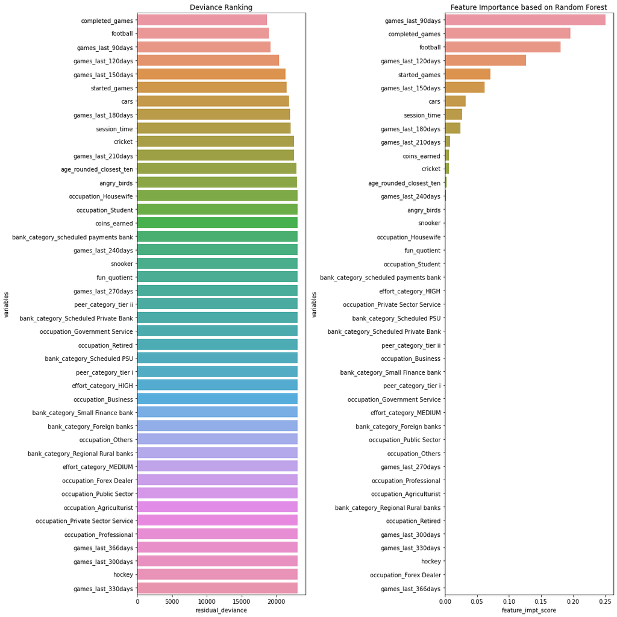

```python
fig,ax = plt.subplots(1,2,figsize=(15,15))
sns.barplot(y="variables", x="residual_deviance",data=deviance_df,ax=ax[0]).set_title("Deviance Ranking")
sns.barplot(y="variables",x="feature_impt_score",data=feature_ranking_df,ax=ax[1]).set_title("Feature Importance based on Random Forest")
plt.tight_layout()
plt.show()
```

## Since the class distributiona among the uninstalled (target) variable is almost equal, we don't use any sampling strategy

```python
x_train, x_test, y_train, y_test = train_test_split(df_copy_x, df_copy_y, test_size=0.2, random_state=12)
```

```python
def log_reg_cv(train_X,train_Y,feature_list):
    f1_list_train=[]
    f1_list_test=[]
    acc_list_train=[]
    acc_list_test=[]
    for i in range(1,len(feature_list)+1):
        cv_results_temp = cross_validate(LogReg(random_state=48,solver='liblinear',penalty="l1"),
                                         train_X.loc[:,feature_list[:i]],train_Y,
                            cv=5,scoring=["accuracy","f1"],return_train_score=True)
        mean_acc_train=np.mean(cv_results_temp["train_accuracy"])
        mean_f1_train=np.mean(cv_results_temp["train_f1"])
        mean_acc_test=np.mean(cv_results_temp["test_accuracy"])
        mean_f1_test=np.mean(cv_results_temp["test_f1"])
        f1_list_train.append(mean_f1_train)
        acc_list_train.append(mean_acc_train)
        f1_list_test.append(mean_f1_test)
        acc_list_test.append(mean_acc_test)
    cv_scoring_df=pd.DataFrame(zip(f1_list_train,f1_list_test,acc_list_train,acc_list_test))
    cv_scoring_df.columns=["Mean F1 Train","Mean F1 Test","Mean Accuracy Train","Mean Accuracy Test"]
    cv_scoring_df.index=cv_scoring_df.index+1
    return cv_scoring_df
```

### A for loop is used for forward selection to determine the number of features to be used using a logistic regression with L1 penalty, a LASSO logistic regression. 2 dataframes will be generated to determine which feature ranking is more suitable for the model based on F1 and accuracy scores.

```python
logreg_cv_scoring_df = log_reg_cv(x_train, y_train, deviance_df.variables)
logreg_cv_scoring_df
```

|  | Mean F1 Train | Mean F1 Test | Mean Accuracy Train | Mean Accuracy Test |
| --- | --- | --- | --- | --- |
| 1 | 0.709145 | 0.709170 | 0.719946 | 0.719946 |
| 2 | 0.739789 | 0.739446 | 0.751898 | 0.751598 |
| 3 | 0.747918 | 0.748463 | 0.758308 | 0.758665 |
| 4 | 0.747428 | 0.747291 | 0.757236 | 0.757086 |
| 5 | 0.748046 | 0.747875 | 0.758270 | 0.758139 |
| 6 | 0.748726 | 0.748518 | 0.759003 | 0.758815 |
| 7 | 0.751569 | 0.751239 | 0.762480 | 0.762199 |
| 8 | 0.756335 | 0.754826 | 0.765995 | 0.764830 |
| 9 | 0.756650 | 0.754781 | 0.766371 | 0.764680 |
| 10 | 0.756758 | 0.754899 | 0.766484 | 0.764830 |
| 11 | 0.771709 | 0.771296 | 0.779415 | 0.778814 |
| 12 | 0.771766 | 0.771595 | 0.779509 | 0.779190 |
| 13 | 0.771952 | 0.771654 | 0.779697 | 0.779265 |
| 14 | 0.771955 | 0.770881 | 0.779622 | 0.778664 |
| 15 | 0.771837 | 0.770789 | 0.779697 | 0.778588 |
| 16 | 0.771954 | 0.771607 | 0.779810 | 0.779340 |
| 17 | 0.772381 | 0.772209 | 0.780167 | 0.779866 |
| 18 | 0.784728 | 0.785184 | 0.790185 | 0.790467 |
| 19 | 0.784895 | 0.784447 | 0.790392 | 0.789715 |
| 20 | 0.785109 | 0.784809 | 0.790617 | 0.790166 |
| 21 | 0.785031 | 0.784773 | 0.790542 | 0.790166 |
| 22 | 0.785036 | 0.784933 | 0.790486 | 0.790242 |
| 23 | 0.785274 | 0.785079 | 0.790730 | 0.790467 |
| 24 | 0.785230 | 0.785429 | 0.790655 | 0.790693 |
| 25 | 0.785553 | 0.785645 | 0.790862 | 0.790843 |
| 26 | 0.785649 | 0.785272 | 0.791031 | 0.790542 |
| 27 | 0.785773 | 0.785904 | 0.791125 | 0.790993 |
| 28 | 0.785866 | 0.785716 | 0.791219 | 0.790843 |
| 29 | 0.786055 | 0.785370 | 0.791350 | 0.790542 |
| 30 | 0.785961 | 0.785187 | 0.791275 | 0.790392 |
| 31 | 0.786326 | 0.785621 | 0.791595 | 0.790768 |
| 32 | 0.786284 | 0.785439 | 0.791595 | 0.790542 |
| 33 | 0.786254 | 0.785281 | 0.791557 | 0.790467 |
| 34 | 0.786184 | 0.785351 | 0.791501 | 0.790392 |
| 35 | 0.786202 | 0.785187 | 0.791482 | 0.790317 |
| 36 | 0.785961 | 0.785255 | 0.791275 | 0.790317 |
| 37 | 0.786256 | 0.785565 | 0.791538 | 0.790617 |
| 38 | 0.786361 | 0.785749 | 0.791670 | 0.790843 |
| 39 | 0.786435 | 0.784922 | 0.791670 | 0.789941 |
| 40 | 0.786464 | 0.784917 | 0.791726 | 0.790016 |
| 41 | 0.786219 | 0.784739 | 0.791463 | 0.789791 |
| 42 | 0.786349 | 0.784668 | 0.791613 | 0.789791 |
| 43 | 0.786397 | 0.784823 | 0.791632 | 0.789941 |

```python
logreg_cv_scoring_df2 = log_reg_cv(x_train,y_train,feature_ranking_df.variables)
logreg_cv_scoring_df2
```

|  | Mean F1 Train | Mean F1 Test | Mean Accuracy Train | Mean Accuracy Test |
| --- | --- | --- | --- | --- |
| 1 | 0.732097 | 0.732132 | 0.728893 | 0.728893 |
| 2 | 0.726754 | 0.726348 | 0.733892 | 0.733478 |
| 3 | 0.747918 | 0.748463 | 0.758308 | 0.758665 |
| 4 | 0.747428 | 0.747195 | 0.757236 | 0.757011 |
| 5 | 0.747687 | 0.746757 | 0.757669 | 0.757011 |
| 6 | 0.748702 | 0.748576 | 0.758984 | 0.758891 |
| 7 | 0.751544 | 0.751338 | 0.762424 | 0.762274 |
| 8 | 0.752311 | 0.751383 | 0.763176 | 0.762424 |
| 9 | 0.756635 | 0.754683 | 0.766352 | 0.764605 |
| 10 | 0.772128 | 0.772182 | 0.779772 | 0.779791 |
| 11 | 0.772126 | 0.772687 | 0.779847 | 0.780242 |
| 12 | 0.771666 | 0.771956 | 0.779415 | 0.779415 |
| 13 | 0.772073 | 0.772255 | 0.779847 | 0.779791 |
| 14 | 0.784230 | 0.784348 | 0.789753 | 0.789715 |
| 15 | 0.784154 | 0.784314 | 0.789771 | 0.789715 |
| 16 | 0.784252 | 0.784096 | 0.789790 | 0.789490 |
| 17 | 0.784527 | 0.784000 | 0.790091 | 0.789415 |
| 18 | 0.784514 | 0.784181 | 0.790053 | 0.789640 |
| 19 | 0.784670 | 0.783992 | 0.790279 | 0.789490 |
| 20 | 0.785131 | 0.784661 | 0.790655 | 0.789941 |
| 21 | 0.785039 | 0.784873 | 0.790448 | 0.790166 |
| 22 | 0.785006 | 0.783927 | 0.790429 | 0.789264 |
| 23 | 0.785175 | 0.784439 | 0.790617 | 0.789866 |
| 24 | 0.785194 | 0.784365 | 0.790580 | 0.789640 |
| 25 | 0.785639 | 0.784644 | 0.791050 | 0.789790 |
| 26 | 0.785281 | 0.784343 | 0.790749 | 0.789715 |
| 27 | 0.785463 | 0.783701 | 0.790862 | 0.789039 |
| 28 | 0.785751 | 0.783702 | 0.791106 | 0.789039 |
| 29 | 0.785657 | 0.784538 | 0.791031 | 0.789866 |
| 30 | 0.785777 | 0.784263 | 0.791087 | 0.789490 |
| 31 | 0.785977 | 0.784394 | 0.791294 | 0.789565 |
| 32 | 0.785769 | 0.784827 | 0.791068 | 0.789941 |
| 33 | 0.785705 | 0.784333 | 0.791050 | 0.789490 |
| 34 | 0.785698 | 0.784485 | 0.791031 | 0.789640 |
| 35 | 0.785984 | 0.784537 | 0.791294 | 0.789790 |
| 36 | 0.786264 | 0.784632 | 0.791538 | 0.789866 |
| 37 | 0.786232 | 0.784148 | 0.791519 | 0.789339 |
| 38 | 0.786375 | 0.785012 | 0.791595 | 0.790091 |
| 39 | 0.786457 | 0.784917 | 0.791707 | 0.790016 |
| 40 | 0.786210 | 0.784814 | 0.791482 | 0.790091 |
| 41 | 0.786434 | 0.785043 | 0.791689 | 0.790091 |
| 42 | 0.786411 | 0.784974 | 0.791670 | 0.790091 |
| 43 | 0.786434 | 0.784798 | 0.791689 | 0.789866 |

```python
log_reg_final = LogReg(random_state = 48, solver='liblinear', penalty='l1')
log_reg_final.fit(x_train.loc[:,feature_ranking_df.variables],y_train)
y_train_pred = log_reg_final.predict(x_train.loc[:,feature_ranking_df.variables])
y_test_pred = log_reg_final.predict(x_test.loc[:,feature_ranking_df.variables])
```

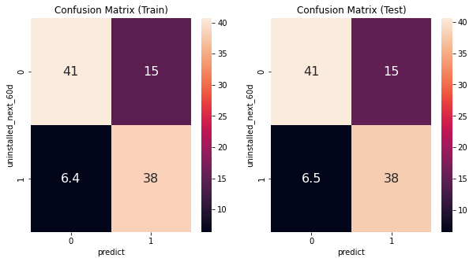

```python
cf_train=pd.DataFrame(pd.crosstab(y_train, y_train_pred, normalize=True, colnames=["predict"])*100)
cf_test=pd.DataFrame(pd.crosstab(y_test,y_test_pred, normalize=True, colnames=["predict"])*100)

fig,ax=plt.subplots(1,2,figsize=(10,5))
sns.heatmap(cf_train,annot=True, annot_kws={"size": 16},ax=ax[0]).set_title("Confusion Matrix (Train)")
sns.heatmap(cf_test,annot=True, annot_kws={"size": 16},ax=ax[1]).set_title("Confusion Matrix (Test)")
plt.show()
```

#### Looking at the confusion matrices (in original code), there is no overfitting or underfitting issue.

```python
train_log_reg_f1 = round(f1_score(y_train, y_train_pred)*100,2)
test_log_reg_f1 = round(f1_score(y_test, y_test_pred)*100,2)

print("F1 Score for train:",train_log_reg_f1)
print("F1 Score for test:",test_log_reg_f1)
```

```
F1 Score for train: 78.53
F1 Score for test: 77.8
```

```python
coef_exp=np.exp(log_reg_final.coef_[0])
coef_exp_df=pd.DataFrame(zip(feature_ranking_df.variables,coef_exp))
coef_exp_df.columns=["Variables","Coef (Exp)"]
coef_exp_df.loc[15]=["intercept",np.exp(log_reg_final.intercept_[0])]
coef_exp_df
```

|  | Variables | Coef (Exp) |
| --- | --- | --- |
| 0 | games_last_90days | 1.090929 |
| 1 | completed_games | 0.916409 |
| 2 | football | 0.935537 |
| 3 | games_last_120days | 1.103617 |
| 4 | started_games | 1.000991 |
| 5 | games_last_150days | 1.097585 |
| 6 | cars | 0.978648 |
| 7 | session_time | 0.999970 |
| 8 | games_last_180days | 1.110553 |
| 9 | games_last_210days | 1.107073 |
| 10 | coins_earned | 0.999961 |
| 11 | cricket | 0.990875 |
| 12 | age_rounded_closest_ten | 1.001018 |
| 13 | games_last_240days | 1.114677 |
| 14 | angry_birds | 0.979843 |
| 15 | intercept | 2.576046 |
| 16 | occupation_Housewife | 0.906596 |
| 17 | fun_quotient | 1.002401 |
| 18 | occupation_Student | 1.025450 |
| 19 | bank_category_scheduled payments bank | 1.720273 |
| 20 | effort_category_HIGH | 1.038311 |
| 21 | occupation_Private Sector Service | 0.936318 |
| 22 | bank_category_Scheduled PSU | 1.228785 |
| 23 | bank_category_Scheduled Private Bank | 1.228208 |
| 24 | peer_category_tier ii | 0.967968 |
| 25 | occupation_Business | 1.080531 |
| 26 | bank_category_Small Finance bank | 0.951204 |
| 27 | peer_category_tier i | 1.089770 |
| 28 | occupation_Government Service | 1.015228 |
| 29 | effort_category_MEDIUM | 1.074669 |
| 30 | bank_category_Foreign banks | 0.951573 |
| 31 | occupation_Public Sector | 0.898362 |
| 32 | occupation_Others | 1.000000 |
| 33 | games_last_270days | 1.000000 |
| 34 | occupation_Professional | 1.046546 |
| 35 | occupation_Agriculturist | 0.867101 |
| 36 | bank_category_Regional Rural banks | 1.000000 |
| 37 | occupation_Retired | 1.467398 |
| 38 | games_last_300days | 1.000000 |
| 39 | games_last_330days | 1.000000 |
| 40 | hockey | 1.000000 |
| 41 | occupation_Forex Dealer | 1.000000 |
| 42 | games_last_366days | 1.000000 |

# Decision Tree

### In this section, we will look at the performance of decision tree. Before that, grid search is used to find the best hyperparameters for decision tree. Since decision tree is easily overfitting, the decision tree is limited to a maximum depth of 4 with maximum number of features of 5.

```python
dtree_parameters={'max_depth':[3,4],
                  'max_features':[2,3,4,5],
                  'min_samples_leaf':[5,10,20,30],
                  'min_samples_split':[5,10,20,30]}
dtree=dtree_clf(random_state=48)
dtree_gridsearch=gridCV(dtree,dtree_parameters,scoring="f1",verbose=1)
dtree_gridsearch.fit(x_train, y_train)
```

```
Fitting 5 folds for each of 128 candidates, totalling 640 fits
```

```
GridSearchCV(estimator=DecisionTreeClassifier(random_state=48),
             param_grid={'max_depth': [3, 4], 'max_features': [2, 3, 4, 5],
                         'min_samples_leaf': [5, 10, 20, 30],
                         'min_samples_split': [5, 10, 20, 30]},
             scoring='f1', verbose=1)
```

```python
dtree_gridsearch.best_params_
```

```
{'max_depth': 4,
 'max_features': 4,
 'min_samples_leaf': 10,
 'min_samples_split': 5}
```

```python
def dtree_cv(train_X, train_Y, feature_list, n):
    f1_list_train=[]
    f1_list_test=[]
    acc_list_train=[]
    acc_list_test=[]
    cv_results_temp = cross_validate(dtree_clf(max_depth=4, max_features=5, min_samples_leaf=10,min_samples_split=5,random_state=48),
                                     train_X.loc[:,feature_list[:n]],train_Y, cv=5, scoring=["accuracy","f1"], return_train_score=True)

    mean_acc_train=np.mean(cv_results_temp["train_accuracy"])
    mean_f1_train=np.mean(cv_results_temp["train_f1"])
    mean_acc_test=np.mean(cv_results_temp["test_accuracy"])
    mean_f1_test=np.mean(cv_results_temp["test_f1"])

    f1_list_train.append(mean_f1_train)
    acc_list_train.append(mean_acc_train)
    f1_list_test.append(mean_f1_test)
    acc_list_test.append(mean_acc_test)

    cv_scoring_df=pd.DataFrame(zip(f1_list_train,f1_list_test,acc_list_train,acc_list_test))
    cv_scoring_df.columns=["Mean F1 Train","Mean F1 Test","Mean Accuracy Train","Mean Accuracy Test"]

    return cv_scoring_df
```

### A for loop is created to do cross validation on decision tree using top 5 features.

```python
dtree_cv_scoring_df = dtree_cv(x_train, y_train, deviance_df.variables, 5)
dtree_cv_scoring_df
```

|  | Mean F1 Train | Mean F1 Test | Mean Accuracy Train | Mean Accuracy Test |
| --- | --- | --- | --- | --- |
| 0 | 0.746717 | 0.742052 | 0.769529 | 0.765281 |

```python
dtree_cv_scoring_df2 = dtree_cv(x_train, y_train, feature_ranking_df.variables, 5)
dtree_cv_scoring_df2
```

|  | Mean F1 Train | Mean F1 Test | Mean Accuracy Train | Mean Accuracy Test |
| --- | --- | --- | --- | --- |
| 0 | 0.746717 | 0.742052 | 0.769529 | 0.765281 |

## Looking at the two dataframes above, the top 5 features works similar in both cases. But compared to logistic regression, the performance is weaker.

```python
dtree_final = dtree_clf(max_depth=4,max_features=5,min_samples_leaf=10,min_samples_split=5,random_state=48)
dtree_final.fit(x_train.loc[:,feature_ranking_df.variables[:5]],y_train)

y_train_dt_pred = dtree_final.predict(x_train.loc[:,feature_ranking_df.variables[:5]])
y_test_dt_pred = dtree_final.predict(x_test.loc[:,feature_ranking_df.variables[:5]])
```

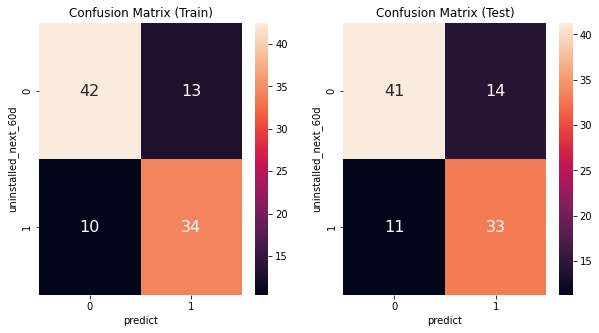

```python
cf_dt_train = pd.DataFrame(pd.crosstab(y_train, y_train_dt_pred, normalize=True, colnames=["predict"])*100)
cf_dt_test = pd.DataFrame(pd.crosstab(y_test, y_test_dt_pred, normalize=True, colnames=["predict"])*100)

fig,ax=plt.subplots(1,2,figsize=(10,5))
sns.heatmap(cf_dt_train, annot=True, annot_kws={"size": 16}, ax=ax[0]).set_title("Confusion Matrix (Train)")
sns.heatmap(cf_dt_test, annot=True, annot_kws={"size": 16}, ax=ax[1]).set_title("Confusion Matrix (Test)")
plt.show()
```

## Looking at the confusion matrices, decision tree is more likely to get false negative as 10% are identified as not uninstalled despite they actually did uninstalled app

```python
train_dt_f1 = round(f1_score(y_train,y_train_dt_pred)*100,2)
test_dt_f1 = round(f1_score(y_test,y_test_dt_pred)*100,2)
print("F1 Score for train:",train_dt_f1)
print("F1 Score for test:",test_dt_f1)
```

```
F1 Score for train: 74.73
F1 Score for test: 71.99
```

## F1 scores for decision tree are close to 74 which are lower than 78 for logistic regression.

```python
dtree_final_txt = tree.export_text(dtree_final, feature_names=list(feature_ranking_df.variables[:5]))
print(dtree_final_txt)
```

```
|--- games_last_90days <= 1.50
|   |--- football <= 6.50
|   |   |--- completed_games <= 26.50
|   |   |   |--- football <= 2.50
|   |   |   |   |--- class: 1
|   |   |   |--- football >  2.50
|   |   |   |   |--- class: 1
|   |   |--- completed_games >  26.50
|   |   |   |--- completed_games <= 67.50
|   |   |   |   |--- class: 1
|   |   |   |--- completed_games >  67.50
|   |   |   |   |--- class: 0
|   |--- football >  6.50
|   |   |--- games_last_120days <= 0.50
|   |   |   |--- football <= 24.50
|   |   |   |   |--- class: 1
|   |   |   |--- football >  24.50
|   |   |   |   |--- class: 0
|   |   |--- games_last_120days >  0.50
|   |   |   |--- games_last_90days <= 0.50
|   |   |   |   |--- class: 0
|   |   |   |--- games_last_90days >  0.50
|   |   |   |   |--- class: 0
|--- games_last_90days >  1.50
|   |--- football <= 15.50
|   |   |--- completed_games <= 70.50
|   |   |   |--- football <= 7.50
|   |   |   |   |--- class: 1
|   |   |   |--- football >  7.50
|   |   |   |   |--- class: 0
|   |   |--- completed_games >  70.50
|   |   |   |--- completed_games <= 126.50
|   |   |   |   |--- class: 0
|   |   |   |--- completed_games >  126.50
|   |   |   |   |--- class: 0
|   |--- football >  15.50
|   |   |--- football <= 41.50
|   |   |   |--- completed_games <= 109.50
|   |   |   |   |--- class: 0
|   |   |   |--- completed_games >  109.50
|   |   |   |   |--- class: 0
|   |   |--- football >  41.50
|   |   |   |--- football <= 61.50
|   |   |   |   |--- class: 0
|   |   |   |--- football >  61.50
|   |   |   |   |--- class: 0
```

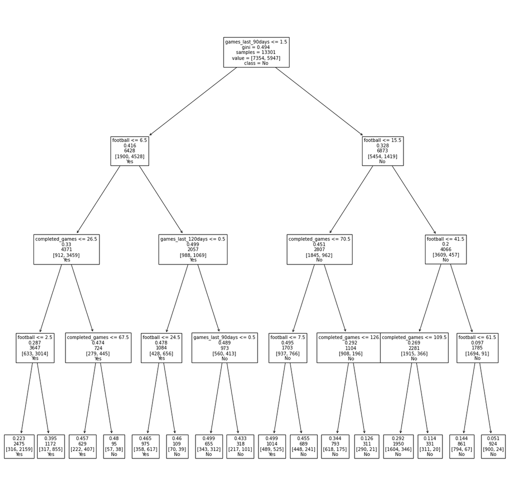

```python
plt.figure(figsize=(20,20))
tree.plot_tree(dtree_final,fontsize=10,feature_names=list(feature_ranking_df.variables[:5]), class_names={0:'No',1:'Yes'},label="root")
plt.show()
```

## Ensemble Learning - Adaboost

### This section will explore using Adaboost classifier to do classification. Adaboost uses multiple decision trees and all the independent features to do classification. Next, Adaboost will identify the misclassified instances and put heavier weights on these instances to train the next decision tree on these instances. By doing so, the misclassification error can be reduced.

```python
adaboost_parameters = {'learning_rate':[0.2,0.4,0.8,1.0]}
adb_clf = adaboost_clf(dtree_clf(max_depth=3), n_estimators=100, random_state=48)
adb_gridsearch=gridCV(adb_clf, adaboost_parameters, scoring="f1", verbose=1)
adb_gridsearch.fit(x_train, y_train)
```

```
Fitting 5 folds for each of 4 candidates, totalling 20 fits
```

```
GridSearchCV(estimator=AdaBoostClassifier(base_estimator=DecisionTreeClassifier(max_depth=3),
                                          n_estimators=100, random_state=48),
             param_grid={'learning_rate': [0.2, 0.4, 0.8, 1.0]}, scoring='f1',
             verbose=1)
```

```python
adb_gridsearch.best_params_
```

```
{'learning_rate': 0.4}
```

```python
adb_clf_final=adaboost_clf(dtree_clf(max_depth=3),random_state=48, n_estimators=100, learning_rate=0.4)
adb_clf_final.fit(x_train, y_train)

y_train_adb_pred = adb_clf_final.predict(x_train)
y_test_adb_pred = adb_clf_final.predict(x_test)
```

### The best learning rate is 0.4. So, Adaboost is being trained again using the train dataset and predicts the classes using train and test sets. The model performance of Adaboost will be evaluated by comparing the actual classes in the train and test sets with the predicted classes.

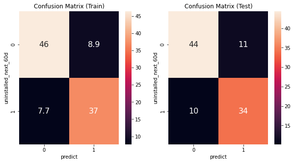

```python
cf_adb_train = pd.DataFrame(pd.crosstab(y_train, y_train_adb_pred, normalize=True, colnames=["predict"])*100)
cf_adb_test = pd.DataFrame(pd.crosstab(y_test, y_test_adb_pred, normalize=True, colnames=["predict"])*100)

fig,ax=plt.subplots(1,2, figsize=(10,5))
sns.heatmap(cf_adb_train, annot=True, annot_kws={"size": 16}, ax=ax[0]).set_title("Confusion Matrix (Train)")
sns.heatmap(cf_adb_test, annot=True, annot_kws={"size": 16}, ax=ax[1]).set_title("Confusion Matrix (Test)")
plt.show()
```

```python
train_adb_f1 = round(f1_score(y_train, y_train_adb_pred)*100,2)
test_adb_f1 = round(f1_score(y_test, y_test_adb_pred)*100,2)

print("F1 Score for train:",train_adb_f1)
print("F1 Score for test:",test_adb_f1)
```

```
F1 Score for train: 81.69
F1 Score for test: 76.1
```

# Ensemble Learning - XGBoost

XGBoost is another popular ensemble learning. It performs better than Adaboost for certain cases as it can:

- randomise the tree or classifier generation which can reduce correlation among the trees or classifiers by randomly selecting the features to be used
- penalise the trees that are rarely used
- more hyperparameters can be trained compared to Adaboost.

```python
import warnings
warnings.filterwarnings('ignore')
```

```python
xgboost_parameters={'learning_rate':[0.2,0.4,0.8,1.0],'gamma':[0,0.2,0.4,0.8],'max_depth':[2,3]}
xgb_clf = xgboost_clf(n_estimators=100,seed=48,objective="binary:logistic",verbosity = 0,reg_lambda=0)
xgb_gridsearch = gridCV(xgb_clf, xgboost_parameters,scoring="f1", verbose=1)
xgb_gridsearch.fit(x_train,  y_train)
```

```
Fitting 5 folds for each of 32 candidates, totalling 160 fits
```

```
GridSearchCV(estimator=XGBClassifier(base_score=None, booster=None,
                                     colsample_bylevel=None,
                                     colsample_bynode=None,
                                     colsample_bytree=None, gamma=None,
                                     gpu_id=None, importance_type='gain',
                                     interaction_constraints=None,
                                     learning_rate=None, max_delta_step=None,
                                     max_depth=None, min_child_weight=None,
                                     missing=nan, monotone_constraints=None,
                                     n_estimators=100, n_jobs=None,
                                     num_parallel_tree=None, random_state=None,
                                     reg_alpha=None, reg_lambda=0,
                                     scale_pos_weight=None, seed=48,
                                     subsample=None, tree_method=None,
                                     validate_parameters=None, verbosity=0),
             param_grid={'gamma': [0, 0.2, 0.4, 0.8],
                         'learning_rate': [0.2, 0.4, 0.8, 1.0],
                         'max_depth': [2, 3]},
             scoring='f1', verbose=1)
```

```python
xgb_gridsearch.best_params_
```

```
{'gamma': 0.2, 'learning_rate': 1.0, 'max_depth': 2}
```

```python
xgb_clf_final=xgboost_clf(max_depth=2,seed=48,n_estimators=100,learning_rate=1,gamma=0.2)
xgb_clf_final.fit(x_train, y_train)

y_train_xgb_pred = xgb_clf_final.predict(x_train)
y_test_xgb_pred = xgb_clf_final.predict(x_test)
```

### XGBoost is retrained using the best parameters from Grid Search and predicted the classses using train and test sets. The model performance is evaluated by comparing the predicted classes with the actual classes in train and test sets.

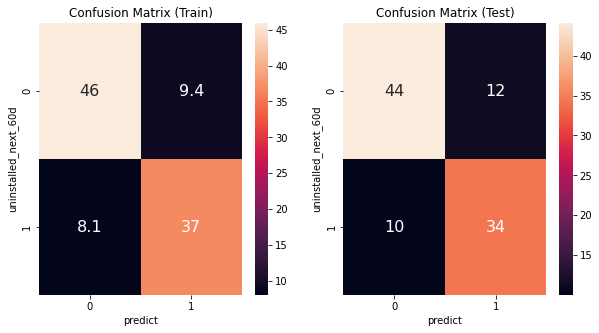

```python
cf_xgb_train = pd.DataFrame(pd.crosstab(y_train, y_train_xgb_pred, normalize=True, colnames=["predict"])*100)
cf_xgb_test = pd.DataFrame(pd.crosstab(y_test, y_test_xgb_pred, normalize=True, colnames=["predict"])*100)

fig,ax=plt.subplots(1,2,figsize=(10,5))
sns.heatmap(cf_xgb_train, annot=True, annot_kws={"size": 16}, ax=ax[0]).set_title("Confusion Matrix (Train)")
sns.heatmap(cf_xgb_test, annot=True, annot_kws={"size": 16}, ax=ax[1]).set_title("Confusion Matrix (Test)")
plt.show()
```

### Looking at the confusion matrices above, there is an indication of overfitting as more instances are wrongly classified in test set.

```python
train_xgb_f1 = round(f1_score(y_train, y_train_xgb_pred)*100,2)
test_xgb_f1 = round(f1_score(y_test, y_test_xgb_pred)*100,2)

print("F1 Score for train:", train_xgb_f1)
print("F1 Score for test:", test_xgb_f1)
```

```
F1 Score for train: 80.78
F1 Score for test: 76.11
```

### F1 score of XGBoost is similar to AdaBoost. Shows overfitting as Train set has higher F1 score as compared to Test set

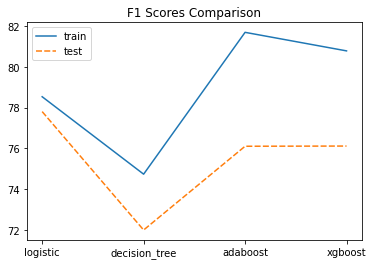

```python
f1_score_dict={"logistic":[train_log_reg_f1, test_log_reg_f1],
               "decision_tree":[train_dt_f1, test_dt_f1],
              "adaboost":[train_adb_f1, test_adb_f1],
               "xgboost":[train_xgb_f1, test_xgb_f1]}

f1_score_df = pd.DataFrame.from_dict(f1_score_dict, orient='index', columns=["train","test"])
sns.lineplot(data=f1_score_df).set_title("F1 Scores Comparison")
plt.show()
```

```python
f1_score_df
```

|  | train | test |
| --- | --- | --- |
| logistic | 78.53 | 77.80 |
| decision_tree | 74.73 | 71.99 |
| adaboost | 81.69 | 76.10 |
| xgboost | 80.78 | 76.11 |

### Comparing F1 scores for 4 different models, Logistic Reg has the best performance compared to other models. It has the highest F1 test score. However, AdaBoost has the highest F1 score in train set compared to other models.

## Conclusison

#### Comparing the performances of the 4 models, Logistic Reg has the best performance since it has the highest F1 score in test set.

#### AdaBoost uses multiple weak classifiers to classify the instances and adjust the classifiers by putting heavier weights on misclassified instances to classify them on the next classifier, but it does not provide a clear interpretation on how the features affect the likelihood of a person uninstalling the app.

#### For a better interpretation, logistic regression provides a better interpretation as it quantifies the effect of each feature to the likelihood of a person uninstalling the app in 60 days and better performance compared to decision tree.

#### Based on the findings from logistic regression uninstalling is mainly driven by completed_games, , started_games, football, games_last_90_days, games_last_120days.